# ML Week4 Project

Rad

10/23/2019

Project Goal

The goal of your project is to predict the manner in which they did the exercise. This is the “classe” variable in the training set. You may use any of the other variables to predict with. You should create a report describing how you built your model, how you used cross validation, what you think the expected out of sample error is, and why you made the choices you did. You will also use your prediction model to predict 20 different test cases.

```r
chooseCRANmirror(graphics=FALSE, ind=1)
knitr::opts_chunk$set(echo = TRUE)
```

```r
# install.packages("caret")
# install.packages("rpart")
# #install.packages("rpart.plot")
# install.packages("randomForest")
#
# install.packages("lmtest", repos = "http://cran.us.r-project.org")

library(caret)
library(rpart)
library(rpart.plot)
library(randomForest)
library(lattice)
library(ggplot2)
```

```r
download.file("https://d396qusza40orc.cloudfront.net/predmachlearn/pml-training.csv",destfile ="training.csv",method="curl", mode="wb")

download.file("https://d396qusza40orc.cloudfront.net/predmachlearn/pml-testing.csv",destfile ="testing.csv",method="curl", mode="wb")


trainingdata<-read.csv("training.csv", header=TRUE, na.strings=c("NA", "", "#DIV/0!"))
testingdata<-read.csv("testing.csv", header=TRUE, na.strings=c("NA", "", "#DIV/0!"))

trainingdata$classe<-as.factor(trainingdata$classe)

table(trainingdata$classe, trainingdata$user_name)
```

```
##
##     adelmo carlitos charles eurico jeremy pedro
##   A   1165      834     899    865   1177   640
##   B    776      690     745    592    489   505
##   C    750      493     539    489    652   499
##   D    515      486     642    582    522   469
##   E    686      609     711    542    562   497
```

```r
which(names(trainingdata) != names(testingdata))
```

```
## [1] 160
```

```r
nas <- apply(trainingdata, 2, function(x) sum(is.na(x)))
trainingdata <- trainingdata[,nas<1000]
testingdata <- testingdata[,nas<1000]
```

Removing first 6 columns since they are not needed for analysis

```r
trainingdata <- trainingdata[,-1:-6]
testingdata <- testingdata[,-1:-6]
```

The following cluster dendogram shows the correlations (R2) between the columns. The formula 1−R2 is used to measure the distance matrix:

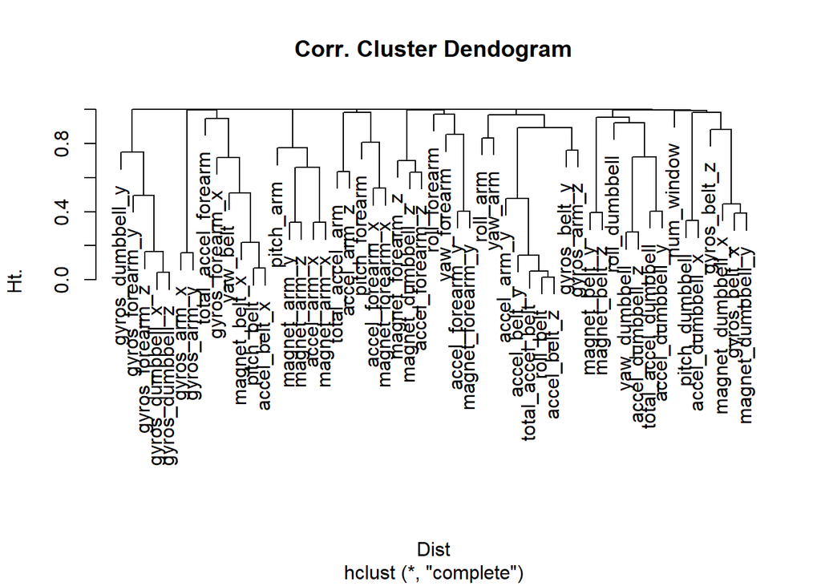

```r
dist <- as.dist(1-(cor(trainingdata[,-54])^2))
plot(hclust(dist),main="Corr. Cluster Dendogram",xlab="Dist",ylab="Ht.")
```

Training data set to 60%, validation set to 40%, 5% data to identify predictors

```r
#install.packages("numDeriv")

tst <- createDataPartition(y=trainingdata$classe, p=0.60, list=FALSE)
training_set  <- trainingdata[tst,]
validation_set  <- trainingdata[-tst,]
trainingsmall <- trainingdata[createDataPartition(y=trainingdata$classe, p=0.05, list=FALSE),]
```

Modeling

```r
rf_model<-train(classe~., data=trainingsmall, method="rf")
varImp(rf_model)
```

```
## rf variable importance
##
##   only 20 most important variables shown (out of 53)
##
##                      Overall
## roll_belt            100.000
## pitch_forearm         79.550
## num_window            79.217
## magnet_dumbbell_z     57.426
## pitch_belt            46.276
## magnet_dumbbell_y     45.178
## yaw_belt              42.616
## roll_dumbbell         34.219
## accel_dumbbell_y      33.996
## magnet_dumbbell_x     28.750
## roll_forearm          24.632
## magnet_belt_y         21.161
## magnet_belt_z         17.028
## total_accel_dumbbell  16.227
## accel_belt_z          14.764
## accel_forearm_x       11.694
## magnet_belt_x         11.277
## gyros_dumbbell_y      10.890
## accel_dumbbell_z      10.487
## accel_dumbbell_x       9.325
```

Narrowed down the variables for further analysis:

```r
top <- cbind(name = rownames(varImp(rf_model)[[1]]), value = varImp(rf_model)[[1]])
selected_data <- as.character(top[order(top[,2], decreasing = T),][1:10,1])

selected_data <- c(selected_data, "classe")

training_set <- training_set[selected_data]
validation_set <- validation_set[selected_data]
```

Checking correlation among variables

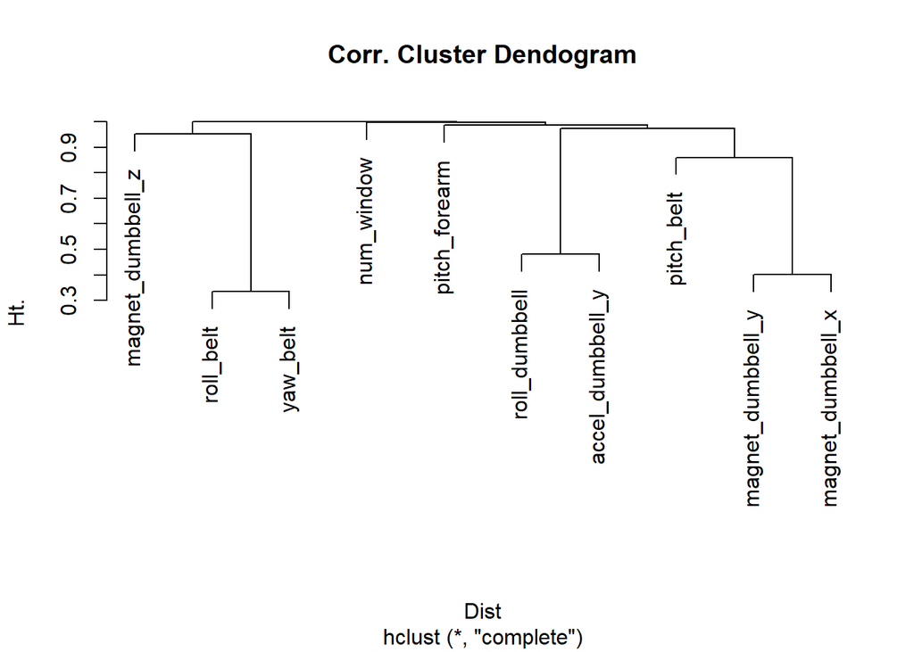

```r
dist <- as.dist(1-(cor(training_set[,-11])^2))


plot(hclust(dist),main="Corr. Cluster Dendogram",xlab="Dist",ylab="Ht.")
```

Random Forest Model

```r
modelRF<-train(classe~., data=training_set, method="rf")
```

Model Validation

```r
predicted <- predict(modelRF, newdata=validation_set)

# false positives, false negatives, true positives, and true negatives.

confusionMatrix(predicted, validation_set$classe)
```

```
## Confusion Matrix and Statistics
##
##           Reference
## Prediction    A    B    C    D    E
##          A 2230    1    0    0    0
##          B    0 1513    4    0    2
##          C    0    3 1364    3    2
##          D    1    0    0 1282    0
##          E    1    1    0    1 1438
##
## Overall Statistics
##
##                Accuracy : 0.9976
##                  95% CI : (0.9962, 0.9985)
##     No Information Rate : 0.2845
##     P-Value [Acc > NIR] : < 2.2e-16
##
##                   Kappa : 0.9969
##
##  Mcnemar's Test P-Value : NA
##
## Statistics by Class:
##
##                      Class: A Class: B Class: C Class: D Class: E
## Sensitivity            0.9991   0.9967   0.9971   0.9969   0.9972
## Specificity            0.9998   0.9991   0.9988   0.9998   0.9995
## Pos Pred Value         0.9996   0.9961   0.9942   0.9992   0.9979
## Neg Pred Value         0.9996   0.9992   0.9994   0.9994   0.9994
## Prevalence             0.2845   0.1935   0.1744   0.1639   0.1838
## Detection Rate         0.2842   0.1928   0.1738   0.1634   0.1833
## Detection Prevalence   0.2843   0.1936   0.1749   0.1635   0.1837
## Balanced Accuracy      0.9995   0.9979   0.9979   0.9984   0.9984
```

SUMMARY Data were cleaned for missing values. Cluster dendrogram used to find correlation. Variables tested for relative importance using random forest model. Shortlisted 10 variables for final calculation.

Prediction

```r
data.frame(testingdata$problem_id, predicted = predict(modelRF, newdata=testingdata))
```

```
##    testingdata.problem_id predicted
## 1                       1         B
## 2                       2         A
## 3                       3         B
## 4                       4         A
## 5                       5         A
## 6                       6         E
## 7                       7         D
## 8                       8         B
## 9                       9         A
## 10                     10         A
## 11                     11         B
## 12                     12         C
## 13                     13         B
## 14                     14         A
## 15                     15         E
## 16                     16         E
## 17                     17         A
## 18                     18         B
## 19                     19         B
## 20                     20         B
```